# The $t$ distribution

DSCI 632: Statistics for Data Science

Peter Ralph

# Stochastic minute: the $t$ distribution

## The $t$ statistic

The $t$ statistic computed from a collection of $n$ numbers is the sample mean divided by the estimated standard error of the mean, which is the sample SD divided by $\sqrt{n}$.

If $x_1, \ldots, x_n$ are numbers, then
$$\begin{aligned}
\text{(sample mean)} \qquad \bar x &= \frac{1}{n}\sum_{i=1}^n
x_i \\
\text{(sample SD)} \qquad s &= \sqrt{\frac{1}{n-1}\sum_{i=1}^n
(x_i - \bar x)^2}
\end{aligned}$$
so
$$\begin{equation}
t(x) = \frac{\bar x}{s / \sqrt{n}} .
\end{equation}$$

## Consistency check

```r
n <- 20
x <- rnorm(n)
c(t.test(x)$statistic,
  mean(x) / (sd(x) / sqrt(n)))
```

```
##        t
## 1.318919 1.318919
```

## The [$t$ distribution](https://en.wikipedia.org/wiki/Student%27s_t-distribution)

(in class: how do you simulate this? `rt`, `pt`, `dt`, etc)

## The $t$ approximation

**Fact:** If $X_1, \ldots, X_n$ are independent random samples from a distribution with mean $\mu$, then
$$\begin{equation}
t(X - \mu) = \frac{\bar x - \mu}{s/\sqrt{n}} \approx
\StudentsT(\text{df}=n-1) ,
\end{equation}$$
as long as $n$ is not too small and the distribution isn’t too wierd.

## A demonstration

lots of times, and looking at the distribution of those $t$ scores.

Claim: no matter${}^*$ the distribution we sample from, the *sampling distribution* of the $t$ statistics should look close to the $t$ distribution.

## One sample

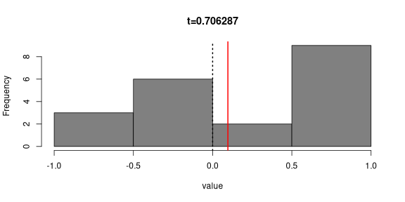

```r
n <- 20
x <- 2 * runif(n) - 1
hist(x, xlab='value', col=grey(0.5),
     main=sprintf("t=%f", mean(x)*sqrt(n)/sd(x)))
abline(v=0, lwd=2, lty=3)
abline(v=mean(x), col='red', lwd=2)
```

## More samples

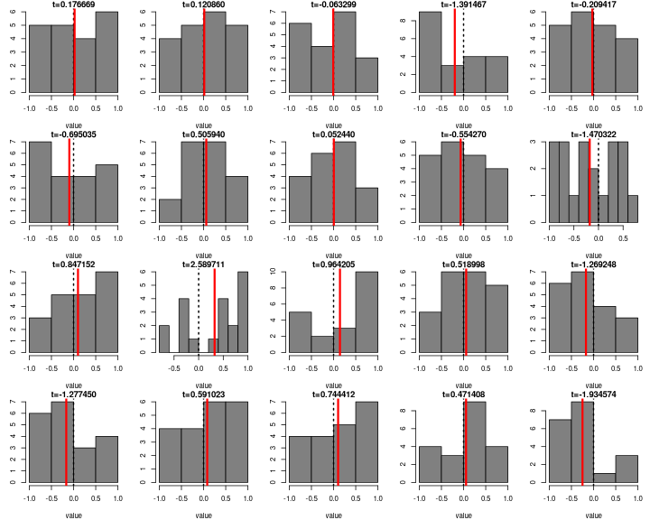

## Distribution of 1,000 sample $t$ scores

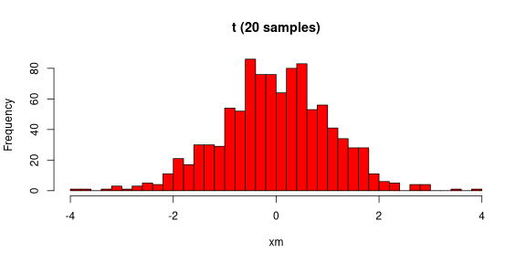

```r
xm <- replicate(1000, {
            x <- 2 * runif(n) - 1;
            mean(x) * sqrt(n) / sd(x) })
xh <- hist(xm, breaks=40, main=sprintf('t (%d samples)', n), col='red')
```

## Distribution of 1,000 sample $t$ scores

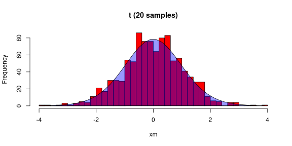

```r
plot(xh, main=sprintf('t (%d samples)', n), col='red')
xx <- xh$breaks
polygon(c(xx[-1] - diff(xx)/2, xx[1]),
        c(length(xm)* diff(pt(xx, df=(n-1))), 0),
        col=adjustcolor("blue", 0.4))
```

## Exercise:

Do this again (use my code) except using

```
x <- rexp(n) - 1
```

instead of `2 * runif(n) - 1`.

**Bonus:** Compare the distribution of these values to draws from the Student’s T distribution (get these from `rt(...)`), using a q-q plot (e.g., with `qqplot()`).

## With an exponential distribution

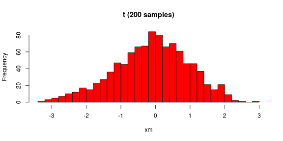

```r
n <- 200
xm <- replicate(1000, {
            x <- rexp(n) - 1;
            mean(x) * sqrt(n) / sd(x) })
xh <- hist(xm, breaks=40, main=sprintf('t (%d samples)', n), col='red')
```

## Note on R’s functions for distributions:

From `?rnorm`:

```
The Normal Distribution
Description
Density, distribution function, quantile function and random generation for the normal distribution with mean equal to mean and standard deviation equal to sd.

Usage
dnorm(x, mean = 0, sd = 1, log = FALSE)
pnorm(q, mean = 0, sd = 1, lower.tail = TRUE, log.p = FALSE)
qnorm(p, mean = 0, sd = 1, lower.tail = TRUE, log.p = FALSE)
rnorm(n, mean = 0, sd = 1)
```

We’ve also got `dexp`, `pexp`, `qexp`, and `rexp`, for instance. Here’s how they are related:

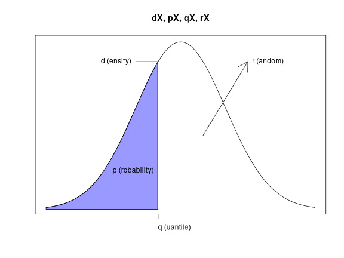